# Capstone 3 / Manipal Hospital NPS Prediction

Sushil Mendon

2023-05-22

## Import Necessary Packages

```r
library(dplyr)
library(readxl)
library(caret)
library(tidyr)
library(pROC)
library(ROSE)
library(rpart)
library(rpart.plot)
library(rattle)
library(RColorBrewer)
library(randomForest)
```

# Import the Dataset

```r
manipal_train <- read_excel("C:/Users/user/Desktop/Sushil/DABS/Capstone 3/NPS_Sreadsheet.xlsx", sheet = 2)
manipal_test <- read_excel("C:/Users/user/Desktop/Sushil/DABS/Capstone 3/NPS_Sreadsheet.xlsx", sheet = 3)

head(manipal_train)
```

```
## # A tibble: 6 × 52
##      SN HospitalNo2 MaritalStatus AgeYrs Sex   BedCategory Department
##   <dbl>       <dbl> <chr>          <dbl> <chr> <chr>       <chr>
## 1     1       35236 Single           4   F     SPECIAL     PEDIATRIC
## 2     2       35237 Single          13   F     SPECIAL     PEDIATRIC
## 3     3       35234 Married         33   F     SEMISPECIAL GYNAEC
## 4     4       35232 Married         51   F     SPECIAL     GYNAEC
## 5     5       35233 Married         31   F     SPECIAL     GYNAEC
## 6     6       35230 Single           0.5 F     SEMISPECIAL PEDIATRIC
## # ℹ 45 more variables: Estimatedcost <dbl>, InsPayorcategory <chr>,
## #   State <chr>, Country <chr>, STATEZONE <chr>, CE_ACCESSIBILITY <dbl>,
## #   CE_CSAT <dbl>, CE_VALUEFORMONEY <dbl>, EM_IMMEDIATEATTENTION <dbl>,
## #   EM_NURSING <dbl>, EM_DOCTOR <dbl>, EM_OVERALL <dbl>, AD_TIME <dbl>,
## #   AD_TARRIFFPACKAGESEXPLAINATION <dbl>, AD_STAFFATTITUDE <dbl>,
## #   INR_ROOMCLEANLINESS <dbl>, INR_ROOMPEACE <dbl>, INR_ROOMEQUIPMENT <dbl>,
## #   INR_ROOMAMBIENCE <dbl>, FNB_FOODQUALITY <dbl>, …
```

```r
head(manipal_test)
```

```
## # A tibble: 6 × 52
##      SN HospitalNo2 MaritalStatus AgeYrs Sex   BedCategory Department
##   <dbl>       <dbl> <chr>          <dbl> <chr> <chr>       <chr>
## 1     1       75949 Single             6 M     GENERAL     PEDIATRIC
## 2     2       12015 Married           65 M     ULTRA SPL   GEN
## 3     3       17250 Married           32 F     GENERAL     GYNAEC
## 4     4       10709 Single             3 F     SPECIAL     GEN
## 5     5       70666 Married           35 M     SPECIAL     GEN
## 6     6       70664 Married           33 F     SPECIAL     GEN
## # ℹ 45 more variables: Estimatedcost <dbl>, InsPayorcategory <chr>,
## #   State <chr>, Country <chr>, STATEZONE <chr>, CE_ACCESSIBILITY <dbl>,
## #   CE_CSAT <dbl>, CE_VALUEFORMONEY <dbl>, EM_IMMEDIATEATTENTION <dbl>,
## #   EM_NURSING <dbl>, EM_DOCTOR <dbl>, EM_OVERALL <dbl>, AD_TIME <dbl>,
## #   AD_TARRIFFPACKAGESEXPLAINATION <dbl>, AD_STAFFATTITUDE <dbl>,
## #   INR_ROOMCLEANLINESS <dbl>, INR_ROOMPEACE <dbl>, INR_ROOMEQUIPMENT <dbl>,
## #   INR_ROOMAMBIENCE <dbl>, FNB_FOODQUALITY <dbl>, …
```

## Description

The `manipal_train` dataset provides information customer satisfaction by patients of Manipal Hospital. The hospital management collected an tabulated scores on multiple parameters on a Likert scale type feedback and on the basis of the same categorised the respondents as “Promotors” or Detractors”.

## Objective and Approach

Manipal Hospital seeks to use its past data to identify Detractors amonst its future patients. The analyst is tasked to use the `manipal_train` data to train multiple Supervised Learning models and make predictions on the `manipal_test` data. The approaches deployed as part of analysis are :

1. Logistic Regression (Including Stepwise and Over-Sampled Models)
2. Decision Tree
3. Random Forest
4. Support Vector Machines(Linear and Radial Models)

## Creating copies of the train and test datasets for further analysis

```r
train <- manipal_train

test <- manipal_test

str(train)
```

```
## tibble [4,989 × 52] (S3: tbl_df/tbl/data.frame)
##  $ SN                            : num [1:4989] 1 2 3 4 5 6 7 8 9 10 ...
##  $ HospitalNo2                   : num [1:4989] 35236 35237 35234 35232 35233 ...
##  $ MaritalStatus                 : chr [1:4989] "Single" "Single" "Married" "Married" ...
##  $ AgeYrs                        : num [1:4989] 4 13 33 51 31 0.5 7 22 65 15 ...
##  $ Sex                           : chr [1:4989] "F" "F" "F" "F" ...
##  $ BedCategory                   : chr [1:4989] "SPECIAL" "SPECIAL" "SEMISPECIAL" "SPECIAL" ...
##  $ Department                    : chr [1:4989] "PEDIATRIC" "PEDIATRIC" "GYNAEC" "GYNAEC" ...
##  $ Estimatedcost                 : num [1:4989] 25000 15000 70000 150000 100000 15000 50000 40000 150000 20000 ...
##  $ InsPayorcategory              : chr [1:4989] "PATIENT" "PATIENT" "EXEMPTION" "PATIENT" ...
##  $ State                         : chr [1:4989] "Karnataka" "Karnataka" "Karnataka" "West Bengal" ...
##  $ Country                       : chr [1:4989] "INDIA" "INDIA" "INDIA" "INDIA" ...
##  $ STATEZONE                     : chr [1:4989] "SOUTH" "SOUTH" "SOUTH" "EAST" ...
##  $ CE_ACCESSIBILITY              : num [1:4989] 4 4 3 4 4 4 3 4 4 4 ...
##  $ CE_CSAT                       : num [1:4989] 4 4 2 4 4 3 3 3 4 4 ...
```

[output cut: 38 more lines]

```r
str(test)
```

```
## tibble [364 × 52] (S3: tbl_df/tbl/data.frame)
##  $ SN                            : num [1:364] 1 2 3 4 5 6 7 8 9 10 ...
##  $ HospitalNo2                   : num [1:364] 75949 12015 17250 10709 70666 ...
##  $ MaritalStatus                 : chr [1:364] "Single" "Married" "Married" "Single" ...
##  $ AgeYrs                        : num [1:364] 6 65 32 3 35 33 73 51 27 30 ...
##  $ Sex                           : chr [1:364] "M" "M" "F" "F" ...
##  $ BedCategory                   : chr [1:364] "GENERAL" "ULTRA SPL" "GENERAL" "SPECIAL" ...
##  $ Department                    : chr [1:364] "PEDIATRIC" "GEN" "GYNAEC" "GEN" ...
##  $ Estimatedcost                 : num [1:364] 20000 40000 50000 70000 70000 50000 40000 100000 80000 55000 ...
##  $ InsPayorcategory              : chr [1:364] "PATIENT" "PATIENT" "EXEMPTION" "CORPORATE" ...
##  $ State                         : chr [1:364] "Karnataka" "Karnataka" "Karnataka" "Karnataka" ...
##  $ Country                       : chr [1:364] "INDIA" "INDIA" "INDIA" "INDIA" ...
##  $ STATEZONE                     : chr [1:364] "SOUTH" "SOUTH" "SOUTH" "SOUTH" ...
##  $ CE_ACCESSIBILITY              : num [1:364] 4 4 4 4 3 4 4 4 4 3 ...
##  $ CE_CSAT                       : num [1:364] 4 4 4 4 3 4 4 3 4 3 ...
```

[output cut: 38 more lines]

# Cleaning & Preparing the Dataset for Analysis

Deleting variables that would not be considered for the analysis. These variables contain serial and identification numbers, geographical information and dates of stay.

```r
train <- train[ , -c(1,2,10:12,48,49)]
test <- test[ , -c(1,2,10:12,48,49)]

str(train)
```

```
## tibble [4,989 × 45] (S3: tbl_df/tbl/data.frame)
##  $ MaritalStatus                 : chr [1:4989] "Single" "Single" "Married" "Married" ...
##  $ AgeYrs                        : num [1:4989] 4 13 33 51 31 0.5 7 22 65 15 ...
##  $ Sex                           : chr [1:4989] "F" "F" "F" "F" ...
##  $ BedCategory                   : chr [1:4989] "SPECIAL" "SPECIAL" "SEMISPECIAL" "SPECIAL" ...
##  $ Department                    : chr [1:4989] "PEDIATRIC" "PEDIATRIC" "GYNAEC" "GYNAEC" ...
##  $ Estimatedcost                 : num [1:4989] 25000 15000 70000 150000 100000 15000 50000 40000 150000 20000 ...
##  $ InsPayorcategory              : chr [1:4989] "PATIENT" "PATIENT" "EXEMPTION" "PATIENT" ...
##  $ CE_ACCESSIBILITY              : num [1:4989] 4 4 3 4 4 4 3 4 4 4 ...
##  $ CE_CSAT                       : num [1:4989] 4 4 2 4 4 3 3 3 4 4 ...
##  $ CE_VALUEFORMONEY              : num [1:4989] 4 4 2 3 4 3 4 3 4 3 ...
##  $ EM_IMMEDIATEATTENTION         : num [1:4989] 4 4 4 4 4 4 4 4 4 3 ...
##  $ EM_NURSING                    : num [1:4989] 4 4 4 4 4 4 4 4 4 4 ...
##  $ EM_DOCTOR                     : num [1:4989] 4 4 4 4 4 4 4 4 4 4 ...
##  $ EM_OVERALL                    : num [1:4989] 4 4 4 4 4 4 3 4 4 4 ...
```

[output cut: 31 more lines]

The Likert scale CSAT scores are being read as numeric. Transforming the same to be ordered factors.

```r
numeric <- c("CE_ACCESSIBILITY", "CE_CSAT", "CE_VALUEFORMONEY", "EM_IMMEDIATEATTENTION",  "EM_NURSING",
             "EM_DOCTOR", "EM_OVERALL", "AD_TIME", "AD_TARRIFFPACKAGESEXPLAINATION", "AD_STAFFATTITUDE",
             "INR_ROOMCLEANLINESS", "INR_ROOMPEACE", "INR_ROOMEQUIPMENT", "INR_ROOMAMBIENCE",
             "FNB_FOODQUALITY", "FNB_FOODDELIVERYTIME", "FNB_DIETICIAN",  "FNB_STAFFATTITUDE",
             "AE_ATTENDEECARE", "AE_PATIENTSTATUSINFO", "AE_ATTENDEEFOOD", "DOC_TREATMENTEXPLAINATION",
             "DOC_ATTITUDE",  "DOC_VISITS", "DOC_TREATMENTEFFECTIVENESS", "NS_CALLBELLRESPONSE",
             "NS_NURSESATTITUDE", "NS_NURSEPROACTIVENESS", "NS_NURSEPATIENCE", "OVS_OVERALLSTAFFATTITUDE",
             "OVS_OVERALLSTAFFPROMPTNESS", "OVS_SECURITYATTITUDE", "DP_DISCHARGETIME","DP_DISCHARGEQUERIES",              "DP_DISCHARGEPROCESS")

train[numeric] <- lapply(train[numeric], factor, levels= c("4","3","2","1"),
                         labels = c("Not at all Satisfied", "Less Satisfied",
                                    "Mostly Satisfied","Extremely Satisfied"),
                         ordered = TRUE)

test[numeric] <- lapply(test[numeric], factor, levels= c("4","3","2","1"),
                        labels = c("Not at all Satisfied", "Less Satisfied",
                                   "Mostly Satisfied","Extremely Satisfied"),
                        ordered = TRUE)


str(train)
```

```
## tibble [4,989 × 45] (S3: tbl_df/tbl/data.frame)
##  $ MaritalStatus                 : chr [1:4989] "Single" "Single" "Married" "Married" ...
##  $ AgeYrs                        : num [1:4989] 4 13 33 51 31 0.5 7 22 65 15 ...
##  $ Sex                           : chr [1:4989] "F" "F" "F" "F" ...
##  $ BedCategory                   : chr [1:4989] "SPECIAL" "SPECIAL" "SEMISPECIAL" "SPECIAL" ...
##  $ Department                    : chr [1:4989] "PEDIATRIC" "PEDIATRIC" "GYNAEC" "GYNAEC" ...
##  $ Estimatedcost                 : num [1:4989] 25000 15000 70000 150000 100000 15000 50000 40000 150000 20000 ...
##  $ InsPayorcategory              : chr [1:4989] "PATIENT" "PATIENT" "EXEMPTION" "PATIENT" ...
##  $ CE_ACCESSIBILITY              : Ord.factor w/ 4 levels "Not at all Satisfied"<..: 1 1 2 1 1 1 2 1 1 1 ...
##  $ CE_CSAT                       : Ord.factor w/ 4 levels "Not at all Satisfied"<..: 1 1 3 1 1 2 2 2 1 1 ...
##  $ CE_VALUEFORMONEY              : Ord.factor w/ 4 levels "Not at all Satisfied"<..: 1 1 3 2 1 2 1 2 1 2 ...
##  $ EM_IMMEDIATEATTENTION         : Ord.factor w/ 4 levels "Not at all Satisfied"<..: 1 1 1 1 1 1 1 1 1 2 ...
##  $ EM_NURSING                    : Ord.factor w/ 4 levels "Not at all Satisfied"<..: 1 1 1 1 1 1 1 1 1 1 ...
##  $ EM_DOCTOR                     : Ord.factor w/ 4 levels "Not at all Satisfied"<..: 1 1 1 1 1 1 1 1 1 1 ...
##  $ EM_OVERALL                    : Ord.factor w/ 4 levels "Not at all Satisfied"<..: 1 1 1 1 1 1 2 1 1 1 ...
```

[output cut: 31 more lines]

Transforming the character variables to factors

```r
train <- as.data.frame(unclass(train), stringsAsFactors = T)
test <- as.data.frame(unclass(test), stringsAsFactors = T)
```

Defining the target variable as Yes and No based on the NPS_Status and converting the same to factor

```r
train$Detractor <- ifelse(train$NPS_Status == "Detractor", "Yes","No")
test$Detractor <- ifelse(test$NPS_Status == "Detractor", "Yes","No")

train$Detractor <- as.factor(train$Detractor)
test$Detractor <- as.factor(test$Detractor)
```

Checking the correlation between CE_NPS and NPS_Status variables

```r
train %>% filter(NPS_Status == "Detractor") %>% summarise(max(CE_NPS))
```

```
##   max(CE_NPS)
## 1           8
```

```r
chisq.test(train$NPS_Status, train$CE_NPS)
```

```
##
##  Pearson's Chi-squared test
##
## data:  train$NPS_Status and train$CE_NPS
## X-squared = 4989, df = 10, p-value < 2.2e-16
```

There is high correlation between CE_NPS and NPS_Status. Observations with score of 8 and below are categorized as Detractors and over 8 are Promoters. Dropping the CE_NPS and NPS_Status variables from train data.

```r
train <- train[ , -c(44, 45)]

str(train)
```

```
## 'data.frame':    4989 obs. of  44 variables:
##  $ MaritalStatus                 : Factor w/ 5 levels "Divorced","Married",..: 4 4 2 2 2 4 4 4 2 4 ...
##  $ AgeYrs                        : num  4 13 33 51 31 0.5 7 22 65 15 ...
##  $ Sex                           : Factor w/ 2 levels "F","M": 1 1 1 1 1 1 1 1 2 1 ...
##  $ BedCategory                   : Factor w/ 11 levels "CCU","DAYCARE",..: 9 9 7 9 9 7 9 3 9 7 ...
##  $ Department                    : Factor w/ 7 levels "CARDIOLOGY","GEN",..: 5 5 3 3 3 5 5 2 6 5 ...
##  $ Estimatedcost                 : num  25000 15000 70000 150000 100000 15000 50000 40000 150000 20000 ...
##  $ InsPayorcategory              : Factor w/ 5 levels "CORPORATE","EXEMPTION",..: 5 5 2 5 3 2 5 3 3 5 ...
##  $ CE_ACCESSIBILITY              : Ord.factor w/ 4 levels "Not at all Satisfied"<..: 1 1 2 1 1 1 2 1 1 1 ...
##  $ CE_CSAT                       : Ord.factor w/ 4 levels "Not at all Satisfied"<..: 1 1 3 1 1 2 2 2 1 1 ...
##  $ CE_VALUEFORMONEY              : Ord.factor w/ 4 levels "Not at all Satisfied"<..: 1 1 3 2 1 2 1 2 1 2 ...
##  $ EM_IMMEDIATEATTENTION         : Ord.factor w/ 4 levels "Not at all Satisfied"<..: 1 1 1 1 1 1 1 1 1 2 ...
##  $ EM_NURSING                    : Ord.factor w/ 4 levels "Not at all Satisfied"<..: 1 1 1 1 1 1 1 1 1 1 ...
##  $ EM_DOCTOR                     : Ord.factor w/ 4 levels "Not at all Satisfied"<..: 1 1 1 1 1 1 1 1 1 1 ...
##  $ EM_OVERALL                    : Ord.factor w/ 4 levels "Not at all Satisfied"<..: 1 1 1 1 1 1 2 1 1 1 ...
```

[output cut: 30 more lines]

```r
str(test)
```

```
## 'data.frame':    364 obs. of  46 variables:
##  $ MaritalStatus                 : Factor w/ 3 levels "Married","Separated",..: 3 1 1 3 1 1 1 1 3 3 ...
##  $ AgeYrs                        : num  6 65 32 3 35 33 73 51 27 30 ...
##  $ Sex                           : Factor w/ 2 levels "F","M": 2 2 1 1 2 1 2 1 2 2 ...
##  $ BedCategory                   : Factor w/ 8 levels "DAYCARE","GENERAL",..: 2 8 2 6 6 6 2 4 2 4 ...
##  $ Department                    : Factor w/ 7 levels "CARDIOLOGY","GEN",..: 5 2 3 2 2 2 6 2 4 2 ...
##  $ Estimatedcost                 : num  20000 40000 50000 70000 70000 50000 40000 100000 80000 55000 ...
##  $ InsPayorcategory              : Factor w/ 4 levels "CORPORATE","EXEMPTION",..: 4 4 2 1 3 4 4 3 4 3 ...
##  $ CE_ACCESSIBILITY              : Ord.factor w/ 4 levels "Not at all Satisfied"<..: 1 1 1 1 2 1 1 1 1 2 ...
##  $ CE_CSAT                       : Ord.factor w/ 4 levels "Not at all Satisfied"<..: 1 1 1 1 2 1 1 2 1 2 ...
##  $ CE_VALUEFORMONEY              : Ord.factor w/ 4 levels "Not at all Satisfied"<..: 2 1 1 1 3 2 1 2 1 2 ...
##  $ EM_IMMEDIATEATTENTION         : Ord.factor w/ 4 levels "Not at all Satisfied"<..: 2 1 1 1 1 1 2 2 2 2 ...
##  $ EM_NURSING                    : Ord.factor w/ 4 levels "Not at all Satisfied"<..: 1 1 1 1 1 1 1 1 2 1 ...
##  $ EM_DOCTOR                     : Ord.factor w/ 4 levels "Not at all Satisfied"<..: 3 1 1 1 1 1 1 2 2 3 ...
##  $ EM_OVERALL                    : Ord.factor w/ 4 levels "Not at all Satisfied"<..: 1 1 1 1 1 1 1 2 2 3 ...
```

[output cut: 32 more lines]

```r
test$NPS_Status <- factor(test$NPS_Status)
```

Normalizing the numerical variables in train and test data

```r
train$AgeYrs <- scale(train$AgeYrs)

train$Estimatedcost <- scale(train$Estimatedcost)

train$LengthofStay <- scale(train$LengthofStay)

test$AgeYrs <- scale(test$AgeYrs)

test$Estimatedcost <- scale(test$Estimatedcost)

test$LengthofStay <- scale(test$LengthofStay)

str(train)
```

```
## 'data.frame':    4989 obs. of  44 variables:
##  $ MaritalStatus                 : Factor w/ 5 levels "Divorced","Married",..: 4 4 2 2 2 4 4 4 2 4 ...
##  $ AgeYrs                        : num [1:4989, 1] -1.577 -1.179 -0.296 0.499 -0.384 ...
##   ..- attr(*, "scaled:center")= num 39.7
##   ..- attr(*, "scaled:scale")= num 22.6
##  $ Sex                           : Factor w/ 2 levels "F","M": 1 1 1 1 1 1 1 1 2 1 ...
##  $ BedCategory                   : Factor w/ 11 levels "CCU","DAYCARE",..: 9 9 7 9 9 7 9 3 9 7 ...
##  $ Department                    : Factor w/ 7 levels "CARDIOLOGY","GEN",..: 5 5 3 3 3 5 5 2 6 5 ...
##  $ Estimatedcost                 : num [1:4989, 1] -0.571 -0.669 -0.13 0.654 0.164 ...
##   ..- attr(*, "scaled:center")= num 83236
##   ..- attr(*, "scaled:scale")= num 102047
##  $ InsPayorcategory              : Factor w/ 5 levels "CORPORATE","EXEMPTION",..: 5 5 2 5 3 2 5 3 3 5 ...
##  $ CE_ACCESSIBILITY              : Ord.factor w/ 4 levels "Not at all Satisfied"<..: 1 1 2 1 1 1 2 1 1 1 ...
##  $ CE_CSAT                       : Ord.factor w/ 4 levels "Not at all Satisfied"<..: 1 1 3 1 1 2 2 2 1 1 ...
##  $ CE_VALUEFORMONEY              : Ord.factor w/ 4 levels "Not at all Satisfied"<..: 1 1 3 2 1 2 1 2 1 2 ...
```

[output cut: 36 more lines]

```r
str(test)
```

```
## 'data.frame':    364 obs. of  46 variables:
##  $ MaritalStatus                 : Factor w/ 3 levels "Married","Separated",..: 3 1 1 3 1 1 1 1 3 3 ...
##  $ AgeYrs                        : num [1:364, 1] -1.2626 1.1975 -0.1785 -1.3877 -0.0534 ...
##   ..- attr(*, "scaled:center")= num 36.3
##   ..- attr(*, "scaled:scale")= num 24
##  $ Sex                           : Factor w/ 2 levels "F","M": 2 2 1 1 2 1 2 1 2 2 ...
##  $ BedCategory                   : Factor w/ 8 levels "DAYCARE","GENERAL",..: 2 8 2 6 6 6 2 4 2 4 ...
##  $ Department                    : Factor w/ 7 levels "CARDIOLOGY","GEN",..: 5 2 3 2 2 2 6 2 4 2 ...
##  $ Estimatedcost                 : num [1:364, 1] -0.6455 -0.4071 -0.288 -0.0496 -0.0496 ...
##   ..- attr(*, "scaled:center")= num 74165
##   ..- attr(*, "scaled:scale")= num 83916
##  $ InsPayorcategory              : Factor w/ 4 levels "CORPORATE","EXEMPTION",..: 4 4 2 1 3 4 4 3 4 3 ...
##  $ CE_ACCESSIBILITY              : Ord.factor w/ 4 levels "Not at all Satisfied"<..: 1 1 1 1 2 1 1 1 1 2 ...
##  $ CE_CSAT                       : Ord.factor w/ 4 levels "Not at all Satisfied"<..: 1 1 1 1 2 1 1 2 1 2 ...
##  $ CE_VALUEFORMONEY              : Ord.factor w/ 4 levels "Not at all Satisfied"<..: 2 1 1 1 3 2 1 2 1 2 ...
```

[output cut: 38 more lines]

# Training Supervised Learning Models on the train data

## Training a Logistic Regression Model for Binomial Classification

```r
set.seed(2205)

lr_mdl1 <- glm(Detractor ~ ., data = train, family = "binomial")
summary(lr_mdl1)
```

```
##
## Call:
## glm(formula = Detractor ~ ., family = "binomial", data = train)
##
## Deviance Residuals:
##     Min       1Q   Median       3Q      Max
## -2.6905  -0.7741  -0.4966   0.8368   2.3765
##
## Coefficients:
##                                    Estimate Std. Error z value Pr(>|z|)
## (Intercept)                       2.620e+01  3.411e+03   0.008 0.993873
## MaritalStatusMarried             -1.568e+01  2.400e+03  -0.007 0.994788
## MaritalStatusSeparated           -3.053e+01  3.393e+03  -0.009 0.992822
## MaritalStatusSingle              -1.554e+01  2.400e+03  -0.006 0.994834
## MaritalStatusWidowed             -1.576e+01  2.400e+03  -0.007 0.994761
## AgeYrs                            1.063e-02  6.027e-02   0.176 0.859960
## SexM                             -6.506e-02  7.536e-02  -0.863 0.387967
## BedCategoryDAYCARE                1.390e+01  2.400e+03   0.006 0.995378
## BedCategoryGENERAL                1.430e+01  2.400e+03   0.006 0.995246
## BedCategoryGENERAL HD             1.473e+01  2.400e+03   0.006 0.995100
## BedCategoryITU                   -9.503e-01  3.393e+03   0.000 0.999777
## BedCategoryRenal ICU             -9.112e-02  2.935e+03   0.000 0.999975
## BedCategorySEMISPECIAL            1.468e+01  2.400e+03   0.006 0.995118
## BedCategorySEMISPECIAL HD         1.391e+01  2.400e+03   0.006 0.995376
## BedCategorySPECIAL                1.466e+01  2.400e+03   0.006 0.995126
## BedCategoryULTRA DLX              1.462e+01  2.400e+03   0.006 0.995139
## BedCategoryULTRA SPL              1.433e+01  2.400e+03   0.006 0.995235
## DepartmentGEN                     1.836e-01  1.600e-01   1.147 0.251332
## DepartmentGYNAEC                  3.050e-01  2.085e-01   1.463 0.143446
## DepartmentORTHO                  -1.121e-01  1.990e-01  -0.563 0.573157
## DepartmentPEDIATRIC               3.873e-01  2.051e-01   1.888 0.058972 .
## DepartmentRENAL                  -2.855e-01  2.360e-01  -1.210 0.226230
## DepartmentSPECIAL                 7.080e-02  1.704e-01   0.415 0.677822
## Estimatedcost                     7.702e-02  4.089e-02   1.884 0.059630 .
## InsPayorcategoryEXEMPTION         1.776e-02  1.838e-01   0.097 0.923058
## InsPayorcategoryINSURANCE         1.959e-01  1.467e-01   1.335 0.181745
## InsPayorcategoryINTERNATIONAL    -2.031e-01  3.461e-01  -0.587 0.557285
## InsPayorcategoryPATIENT           1.636e-01  1.436e-01   1.140 0.254380
## CE_ACCESSIBILITY.L                1.610e+00  6.644e-01   2.423 0.015384 *
## CE_ACCESSIBILITY.Q                5.408e-01  5.159e-01   1.048 0.294462
```

[output cut: 98 more lines]

```
## DP_DISCHARGEQUERIES.C             7.550e-02  1.844e-01   0.409 0.682215
## DP_DISCHARGEPROCESS.L            -8.479e-02  3.983e-01  -0.213 0.831444
## DP_DISCHARGEPROCESS.Q            -8.224e-03  2.456e-01  -0.033 0.973293
## DP_DISCHARGEPROCESS.C            -8.749e-02  1.618e-01  -0.541 0.588616
## LengthofStay                     -5.827e-02  4.028e-02  -1.447 0.148011
## ---
## Signif. codes:  0 '***' 0.001 '**' 0.01 '*' 0.05 '.' 0.1 ' ' 1
##
## (Dispersion parameter for binomial family taken to be 1)
##
##     Null deviance: 6578.3  on 4988  degrees of freedom
## Residual deviance: 4974.3  on 4856  degrees of freedom
## AIC: 5240.3
##
## Number of Fisher Scoring iterations: 15
```

### Making predictions with the model on the test data

“pred <- predict(lr_mdl1, newdata = test, type =”response”)”

“Error in model.frame.default(Terms, newdata, na.action = na.action, xlev = object$xlevels) : factor NS_NURSEPROACTIVENESS has new levels Extremely Satisfied”

```r
summary(train$NS_NURSEPROACTIVENESS)
```

```
## Not at all Satisfied       Less Satisfied     Mostly Satisfied
##                 3459                 1408                  122
##  Extremely Satisfied
##                    0
```

```r
summary(test$NS_NURSEPROACTIVENESS)
```

```
## Not at all Satisfied       Less Satisfied     Mostly Satisfied
##                  212                  129                   19
##  Extremely Satisfied
##                    4
```

There are 4 obesations in the `NS_NURSEPROACTIVENESS` variable in the “Extremely Satisfied” level of the test data but 0 in the train data. Dropping those 4 obersations and attempting to fit the model.

```r
test <- test[!(test$NS_NURSEPROACTIVENESS == "Extremely Satisfied"), ]

pred <- predict(lr_mdl1, newdata = test, type = "response")

test$lr_pred <- ifelse(pred >= 0.5, "Detractor", "Promotor")

test$lr_pred <- as.factor(test$lr_pred)
```

### Checking Model accuracy and fit

```r
confusionMatrix(test$lr_pred, test$NPS_Status, positive = "Detractor")
```

```
## Confusion Matrix and Statistics
##
##            Reference
## Prediction  Detractor Promotor
##   Detractor        81       36
##   Promotor         77      166
##
##                Accuracy : 0.6861
##                  95% CI : (0.6354, 0.7337)
##     No Information Rate : 0.5611
##     P-Value [Acc > NIR] : 7.968e-07
##
##                   Kappa : 0.3442
##
##  Mcnemar's Test P-Value : 0.000168
##
##             Sensitivity : 0.5127
##             Specificity : 0.8218
##          Pos Pred Value : 0.6923
##          Neg Pred Value : 0.6831
##              Prevalence : 0.4389
##          Detection Rate : 0.2250
##    Detection Prevalence : 0.3250
##       Balanced Accuracy : 0.6672
##
##        'Positive' Class : Detractor
##
```

```r
mean(test$lr_pred == test$NPS_Status)
```

```
## [1] 0.6861111
```

```r
LR_ROC <- roc(test$Detractor, pred)
```

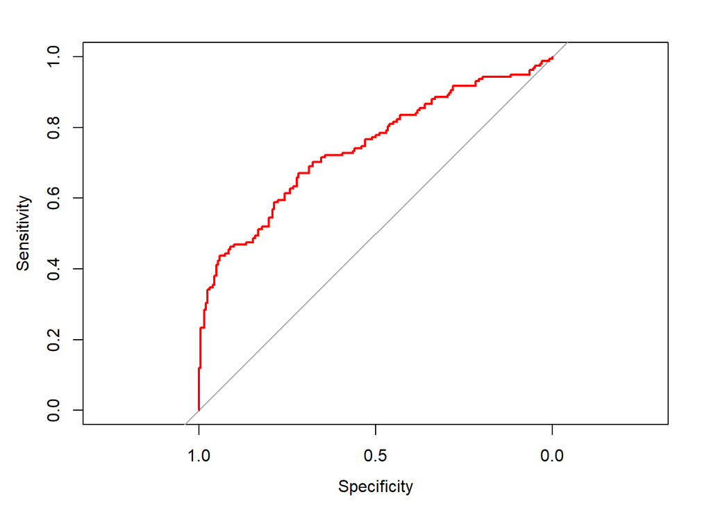

```r
plot(LR_ROC, col = "red")
```

The Logistic Regression Model has an overall accuracy of 68% with Sensitivity & Specificity at 51% and 82% respectively.

## Training a Stepwise Logistic Regression Model for Binomial Classification

```r
set.seed(2205)

null_model <- glm(Detractor ~ 1, data = train, family = "binomial")

step_model <- step(lr_mdl1, scope = list(lower = null_model, upper = lr_mdl1), direction = "backward")
```

```
## Start:  AIC=5240.32
## Detractor ~ MaritalStatus + AgeYrs + Sex + BedCategory + Department +
##     Estimatedcost + InsPayorcategory + CE_ACCESSIBILITY + CE_CSAT +
##     CE_VALUEFORMONEY + EM_IMMEDIATEATTENTION + EM_NURSING + EM_DOCTOR +
##     EM_OVERALL + AD_TIME + AD_TARRIFFPACKAGESEXPLAINATION + AD_STAFFATTITUDE +
##     INR_ROOMCLEANLINESS + INR_ROOMPEACE + INR_ROOMEQUIPMENT +
##     INR_ROOMAMBIENCE + FNB_FOODQUALITY + FNB_FOODDELIVERYTIME +
##     FNB_DIETICIAN + FNB_STAFFATTITUDE + AE_ATTENDEECARE + AE_PATIENTSTATUSINFO +
##     AE_ATTENDEEFOOD + DOC_TREATMENTEXPLAINATION + DOC_ATTITUDE +
##     DOC_VISITS + DOC_TREATMENTEFFECTIVENESS + NS_CALLBELLRESPONSE +
##     NS_NURSESATTITUDE + NS_NURSEPROACTIVENESS + NS_NURSEPATIENCE +
##     OVS_OVERALLSTAFFATTITUDE + OVS_OVERALLSTAFFPROMPTNESS + OVS_SECURITYATTITUDE +
##     DP_DISCHARGETIME + DP_DISCHARGEQUERIES + DP_DISCHARGEPROCESS +
##     LengthofStay
##
##                                  Df Deviance    AIC
## - MaritalStatus                   4   4976.7 5234.7
## - DP_DISCHARGEPROCESS             3   4975.0 5235.0
## - DOC_TREATMENTEFFECTIVENESS      3   4975.3 5235.3
## - AD_TIME                         3   4975.4 5235.4
## - INR_ROOMPEACE                   3   4975.5 5235.5
## - NS_NURSEPATIENCE                3   4975.8 5235.8
## - AE_ATTENDEECARE                 3   4975.8 5235.8
## - DP_DISCHARGETIME                3   4975.8 5235.8
## - FNB_DIETICIAN                   3   4975.9 5235.9
## - FNB_STAFFATTITUDE               3   4976.1 5236.1
## - DOC_ATTITUDE                    3   4976.4 5236.4
## - InsPayorcategory                4   4978.5 5236.5
## - EM_OVERALL                      3   4976.6 5236.6
## - NS_NURSESATTITUDE               3   4976.7 5236.7
## - OVS_OVERALLSTAFFATTITUDE        3   4977.5 5237.5
## - INR_ROOMEQUIPMENT               3   4977.6 5237.6
## - DP_DISCHARGEQUERIES             3   4978.1 5238.1
## - EM_IMMEDIATEATTENTION           3   4978.2 5238.2
## - AgeYrs                          1   4974.4 5238.4
## - OVS_SECURITYATTITUDE            3   4978.9 5238.9
## - Sex                             1   4975.1 5239.1
## - NS_NURSEPROACTIVENESS           2   4977.7 5239.7
## - FNB_FOODQUALITY                 3   4980.0 5240.0
## <none>                                4974.3 5240.3
```

[output cut: 985 more lines]

```
## - DP_DISCHARGEQUERIES             3   5033.7 5171.7
## - NS_NURSEPROACTIVENESS           2   5032.4 5172.4
## - NS_CALLBELLRESPONSE             3   5034.5 5172.5
## - AE_ATTENDEEFOOD                 3   5034.6 5172.6
## - OVS_OVERALLSTAFFPROMPTNESS      3   5035.1 5173.1
## - AE_PATIENTSTATUSINFO            3   5036.9 5174.9
## - DOC_VISITS                      3   5040.7 5178.7
## - Department                      6   5048.3 5180.3
## - AD_STAFFATTITUDE                3   5042.9 5180.9
## - FNB_FOODDELIVERYTIME            3   5043.2 5181.2
## - BedCategory                    10   5057.6 5181.6
## - CE_ACCESSIBILITY                3   5052.5 5190.5
## - AD_TARRIFFPACKAGESEXPLAINATION  3   5060.0 5198.0
## - CE_VALUEFORMONEY                3   5107.5 5245.5
## - CE_CSAT                         3   5118.5 5256.5
```

```r
summary(step_model)
```

```
##
## Call:
## glm(formula = Detractor ~ BedCategory + Department + Estimatedcost +
##     CE_ACCESSIBILITY + CE_CSAT + CE_VALUEFORMONEY + EM_NURSING +
##     EM_DOCTOR + AD_TARRIFFPACKAGESEXPLAINATION + AD_STAFFATTITUDE +
##     INR_ROOMCLEANLINESS + INR_ROOMAMBIENCE + FNB_FOODDELIVERYTIME +
##     AE_PATIENTSTATUSINFO + AE_ATTENDEEFOOD + DOC_TREATMENTEXPLAINATION +
##     DOC_VISITS + NS_CALLBELLRESPONSE + NS_NURSEPROACTIVENESS +
##     OVS_OVERALLSTAFFPROMPTNESS + DP_DISCHARGEQUERIES + LengthofStay,
##     family = "binomial", data = train)
##
## Deviance Residuals:
##     Min       1Q   Median       3Q      Max
## -2.7367  -0.7806  -0.5021   0.8553   2.3626
##
## Coefficients:
##                                    Estimate Std. Error z value Pr(>|z|)
## (Intercept)                      -1.325e+00  2.408e+03  -0.001 0.999561
## BedCategoryDAYCARE                1.422e+01  2.400e+03   0.006 0.995271
## BedCategoryGENERAL                1.454e+01  2.400e+03   0.006 0.995167
## BedCategoryGENERAL HD             1.497e+01  2.400e+03   0.006 0.995022
## BedCategoryITU                   -7.100e-01  3.393e+03   0.000 0.999833
## BedCategoryRenal ICU              2.067e-01  2.935e+03   0.000 0.999944
## BedCategorySEMISPECIAL            1.495e+01  2.400e+03   0.006 0.995028
## BedCategorySEMISPECIAL HD         1.432e+01  2.400e+03   0.006 0.995239
## BedCategorySPECIAL                1.493e+01  2.400e+03   0.006 0.995034
## BedCategoryULTRA DLX              1.486e+01  2.400e+03   0.006 0.995057
## BedCategoryULTRA SPL              1.461e+01  2.400e+03   0.006 0.995142
## DepartmentGEN                     2.790e-01  1.471e-01   1.897 0.057790 .
## DepartmentGYNAEC                  3.262e-01  1.932e-01   1.688 0.091387 .
## DepartmentORTHO                  -1.675e-02  1.908e-01  -0.088 0.930064
## DepartmentPEDIATRIC               5.375e-01  1.689e-01   3.182 0.001460 **
## DepartmentRENAL                  -2.255e-01  2.262e-01  -0.997 0.318820
## DepartmentSPECIAL                 1.200e-01  1.631e-01   0.736 0.461755
## Estimatedcost                     6.313e-02  3.911e-02   1.614 0.106517
## CE_ACCESSIBILITY.L                1.554e+00  6.579e-01   2.362 0.018174 *
## CE_ACCESSIBILITY.Q                4.865e-01  5.093e-01   0.955 0.339450
## CE_ACCESSIBILITY.C               -4.071e-01  2.823e-01  -1.442 0.149230
## CE_CSAT.L                         1.222e+00  5.684e-01   2.151 0.031509 *
## CE_CSAT.Q                        -9.499e-01  4.615e-01  -2.059 0.039536 *
```

[output cut: 44 more lines]

```
## OVS_OVERALLSTAFFPROMPTNESS.C     -5.768e-01  3.076e-01  -1.875 0.060749 .
## DP_DISCHARGEQUERIES.L             4.906e-01  2.907e-01   1.688 0.091467 .
## DP_DISCHARGEQUERIES.Q            -1.323e-02  2.336e-01  -0.057 0.954852
## DP_DISCHARGEQUERIES.C            -4.463e-03  1.659e-01  -0.027 0.978534
## LengthofStay                     -6.862e-02  3.930e-02  -1.746 0.080794 .
## ---
## Signif. codes:  0 '***' 0.001 '**' 0.01 '*' 0.05 '.' 0.1 ' ' 1
##
## (Dispersion parameter for binomial family taken to be 1)
##
##     Null deviance: 6578.3  on 4988  degrees of freedom
## Residual deviance: 5024.0  on 4917  degrees of freedom
## AIC: 5168
##
## Number of Fisher Scoring iterations: 15
```

### Making predictions with the model on the test data

```r
step_pred <- predict(step_model, newdata = test, type = "response")

test$step_pred <- ifelse(step_pred >= 0.5, "Detractor", "Promotor")

test$step_pred <- as.factor(test$step_pred)
```

### Checking Model accuracy and fit

```r
confusionMatrix(test$step_pred, test$NPS_Status, positive = "Detractor")
```

```
## Confusion Matrix and Statistics
##
##            Reference
## Prediction  Detractor Promotor
##   Detractor        82       32
##   Promotor         76      170
##
##                Accuracy : 0.7
##                  95% CI : (0.6498, 0.7469)
##     No Information Rate : 0.5611
##     P-Value [Acc > NIR] : 4.337e-08
##
##                   Kappa : 0.3718
##
##  Mcnemar's Test P-Value : 3.508e-05
##
##             Sensitivity : 0.5190
##             Specificity : 0.8416
##          Pos Pred Value : 0.7193
##          Neg Pred Value : 0.6911
##              Prevalence : 0.4389
##          Detection Rate : 0.2278
##    Detection Prevalence : 0.3167
##       Balanced Accuracy : 0.6803
##
##        'Positive' Class : Detractor
##
```

```r
mean(test$step_pred == test$NPS_Status)
```

```
## [1] 0.7
```

```r
step_ROC <- roc(test$Detractor, step_pred)
```

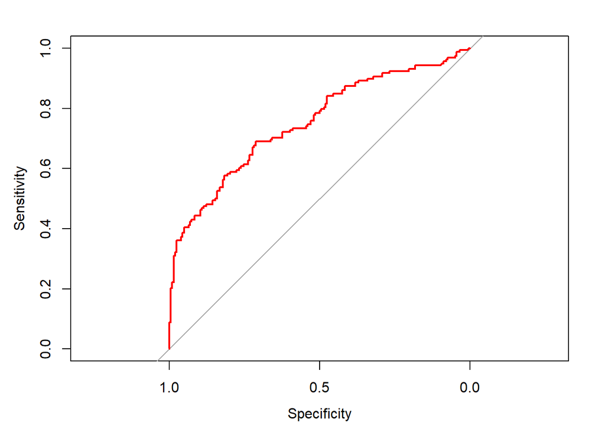

```r
plot(step_ROC, col = "red")
```

The Step-wise Logistic Regression Model has an overall accuracy of 70% with Sensitivity & Specificity at 51% and 84% respectively.

## Training an Over-Sampled Logistic Regression Model for Binomial Classification

```r
set.seed(2205)

over <- ovun.sample(Detractor ~ ., data = train, method = "over", N = 6280)$data

lr_mdl_over <- glm(Detractor ~ ., data = over, family = "binomial")
summary(lr_mdl_over)
```

```
##
## Call:
## glm(formula = Detractor ~ ., family = "binomial", data = over)
##
## Deviance Residuals:
##     Min       1Q   Median       3Q      Max
## -2.7493  -0.8345  -0.0001   0.8889   2.1764
##
## Coefficients:
##                                    Estimate Std. Error z value Pr(>|z|)
## (Intercept)                       2.933e+01  4.589e+03   0.006 0.994901
## MaritalStatusMarried             -1.611e+01  2.284e+03  -0.007 0.994374
## MaritalStatusSeparated           -3.233e+01  4.568e+03  -0.007 0.994354
## MaritalStatusSingle              -1.600e+01  2.284e+03  -0.007 0.994412
## MaritalStatusWidowed             -3.138e+01  2.372e+03  -0.013 0.989445
## AgeYrs                            4.672e-02  5.186e-02   0.901 0.367568
## SexM                             -7.117e-02  6.520e-02  -1.092 0.275013
## BedCategoryDAYCARE                1.545e+01  3.956e+03   0.004 0.996883
## BedCategoryGENERAL                1.591e+01  3.956e+03   0.004 0.996791
## BedCategoryGENERAL HD             1.624e+01  3.956e+03   0.004 0.996725
## BedCategoryITU                   -8.725e-01  5.595e+03   0.000 0.999876
## BedCategoryRenal ICU              1.380e-02  4.841e+03   0.000 0.999998
## BedCategorySEMISPECIAL            1.625e+01  3.956e+03   0.004 0.996722
## BedCategorySEMISPECIAL HD         1.499e+01  3.956e+03   0.004 0.996977
## BedCategorySPECIAL                1.621e+01  3.956e+03   0.004 0.996730
## BedCategoryULTRA DLX              1.605e+01  3.956e+03   0.004 0.996762
## BedCategoryULTRA SPL              1.596e+01  3.956e+03   0.004 0.996780
## DepartmentGEN                     2.302e-01  1.368e-01   1.683 0.092420 .
## DepartmentGYNAEC                  3.938e-01  1.793e-01   2.197 0.028020 *
## DepartmentORTHO                  -6.105e-02  1.685e-01  -0.362 0.717113
## DepartmentPEDIATRIC               5.823e-01  1.762e-01   3.305 0.000949 ***
## DepartmentRENAL                  -3.051e-01  2.021e-01  -1.509 0.131270
## DepartmentSPECIAL                 2.963e-02  1.465e-01   0.202 0.839686
## Estimatedcost                     8.365e-02  3.458e-02   2.419 0.015573 *
## InsPayorcategoryEXEMPTION         6.475e-02  1.589e-01   0.407 0.683686
## InsPayorcategoryINSURANCE         2.324e-01  1.275e-01   1.823 0.068249 .
## InsPayorcategoryINTERNATIONAL    -1.751e-01  2.901e-01  -0.603 0.546182
## InsPayorcategoryPATIENT           2.782e-01  1.243e-01   2.239 0.025174 *
## CE_ACCESSIBILITY.L                9.335e-01  6.369e-01   1.466 0.142725
## CE_ACCESSIBILITY.Q               -6.253e-02  4.916e-01  -0.127 0.898769
```

[output cut: 98 more lines]

```
## DP_DISCHARGEQUERIES.C             3.466e-02  1.699e-01   0.204 0.838329
## DP_DISCHARGEPROCESS.L             9.693e-02  3.717e-01   0.261 0.794289
## DP_DISCHARGEPROCESS.Q            -5.702e-02  2.235e-01  -0.255 0.798612
## DP_DISCHARGEPROCESS.C            -2.863e-02  1.443e-01  -0.198 0.842672
## LengthofStay                     -9.612e-02  3.667e-02  -2.621 0.008768 **
## ---
## Signif. codes:  0 '***' 0.001 '**' 0.01 '*' 0.05 '.' 0.1 ' ' 1
##
## (Dispersion parameter for binomial family taken to be 1)
##
##     Null deviance: 8705.9  on 6279  degrees of freedom
## Residual deviance: 6572.9  on 6147  degrees of freedom
## AIC: 6838.9
##
## Number of Fisher Scoring iterations: 16
```

### Making predictions with the model on the test data

```r
over_pred <- predict(lr_mdl_over, newdata = test, type = "response")

test$over_pred <- ifelse(over_pred >= 0.5, "Detractor", "Promotor")

test$over_pred <- as.factor(test$over_pred)
```

### Checking Model accuracy and fit

```r
confusionMatrix(test$over_pred, test$NPS_Status, positive = "Detractor")
```

```
## Confusion Matrix and Statistics
##
##            Reference
## Prediction  Detractor Promotor
##   Detractor        96       59
##   Promotor         62      143
##
##                Accuracy : 0.6639
##                  95% CI : (0.6125, 0.7125)
##     No Information Rate : 0.5611
##     P-Value [Acc > NIR] : 4.408e-05
##
##                   Kappa : 0.3162
##
##  Mcnemar's Test P-Value : 0.8557
##
##             Sensitivity : 0.6076
##             Specificity : 0.7079
##          Pos Pred Value : 0.6194
##          Neg Pred Value : 0.6976
##              Prevalence : 0.4389
##          Detection Rate : 0.2667
##    Detection Prevalence : 0.4306
##       Balanced Accuracy : 0.6578
##
##        'Positive' Class : Detractor
##
```

```r
mean(test$over_pred == test$NPS_Status)
```

```
## [1] 0.6638889
```

```r
over_ROC <- roc(test$Detractor, over_pred)
```

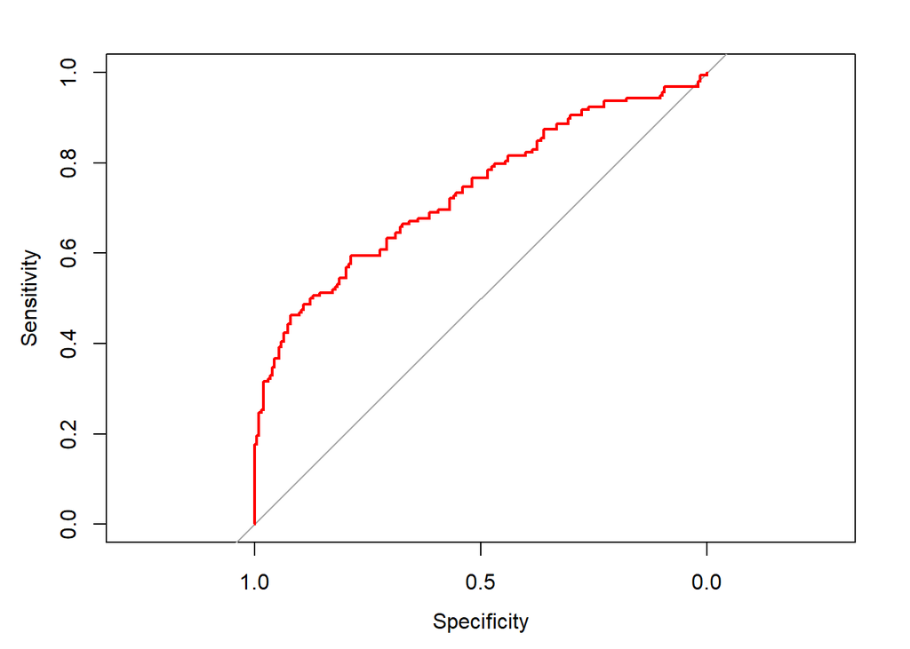

```r
plot(over_ROC, col = "red")
```

The Over-Sampled Logistic Regression Model has an overall accuracy of 66% with Sensitivity & Specificity at 60% and 70% respectively.

## Training a Decision Tree Model for Binomial Classification

```r
set.seed(2205)

dt_model <- rpart(Detractor ~ ., data = train, method = "class", control = rpart.control(cp = 0))

summary(dt_model)
```

```
## Call:
## rpart(formula = Detractor ~ ., data = train, method = "class",
##     control = rpart.control(cp = 0))
##   n= 4989
##
##              CP nsplit rel error    xerror       xstd
## 1  0.1768523526      0 1.0000000 1.0000000 0.01844971
## 2  0.0475932937      1 0.8231476 0.8231476 0.01758898
## 3  0.0308274743      3 0.7279611 0.7333694 0.01699491
## 4  0.0113574905      4 0.6971336 0.7095727 0.01681783
## 5  0.0070308275      5 0.6857761 0.7009194 0.01675130
## 6  0.0048674959      6 0.6787453 0.6960519 0.01671336
## 7  0.0043266631      9 0.6641428 0.6933478 0.01669213
## 8  0.0036055526     10 0.6598161 0.6928069 0.01668786
## 9  0.0032449973     19 0.6170903 0.6901028 0.01666649
## 10 0.0029745809     21 0.6106003 0.6868578 0.01664069
## 11 0.0027041644     24 0.5997837 0.6868578 0.01664069
## 12 0.0023436092     28 0.5889670 0.6782044 0.01657106
## 13 0.0018929151     31 0.5819362 0.6782044 0.01657106
## 14 0.0016224986     35 0.5743645 0.6749594 0.01654465
## 15 0.0014422210     51 0.5462412 0.6798269 0.01658421
## 16 0.0012168740     54 0.5419145 0.6868578 0.01664069
## 17 0.0011898323     60 0.5321796 0.6884803 0.01665361
## 18 0.0010816658     67 0.5219037 0.6906436 0.01667077
## 19 0.0009734992     81 0.5067604 0.6938886 0.01669638
## 20 0.0009013881     86 0.5018929 0.6965928 0.01671760
## 21 0.0008112493     89 0.4991888 0.6998378 0.01674290
## 22 0.0007211105     97 0.4926988 0.7036236 0.01677222
## 23 0.0006610180    100 0.4905354 0.7036236 0.01677222
## 24 0.0005408329    112 0.4818821 0.7133586 0.01684658
## 25 0.0002403702    128 0.4732288 0.7306652 0.01697522
## 26 0.0002028123    141 0.4689021 0.7441860 0.01707259
## 27 0.0001802776    149 0.4672796 0.7501352 0.01711459
## 28 0.0001545237    155 0.4661979 0.7517577 0.01712595
## 29 0.0001352082    162 0.4651163 0.7555435 0.01715231
## 30 0.0001081666    170 0.4640346 0.7560844 0.01715606
## 31 0.0000000000    175 0.4634938 0.7577069 0.01716729
##
## Variable importance
##                        CE_CSAT               CE_VALUEFORMONEY
```

[output cut: 3846 more lines]

```
##
## Node number 223279: 8 observations
##   predicted class=Yes  expected loss=0.25  P(node) =0.001603528
##     class counts:     2     6
##    probabilities: 0.250 0.750
##
## Node number 330022: 27 observations
##   predicted class=No   expected loss=0.1481481  P(node) =0.005411906
##     class counts:    23     4
##    probabilities: 0.852 0.148
##
## Node number 330023: 13 observations
##   predicted class=Yes  expected loss=0.4615385  P(node) =0.002605733
##     class counts:     6     7
##    probabilities: 0.462 0.538
```

### Making predictions with the model on the test data

```r
test$dt_pred <- predict(dt_model, newdata = test, type = "class")

test$dt_pred <- ifelse(test$dt_pred == "Yes", "Detractor","Promotor")

test$dt_pred <- as.factor(test$dt_pred)
```

### Checking Model accuracy and fit

```r
confusionMatrix(test$dt_pred, test$NPS_Status, positive = "Detractor")
```

```
## Confusion Matrix and Statistics
##
##            Reference
## Prediction  Detractor Promotor
##   Detractor        94       59
##   Promotor         64      143
##
##                Accuracy : 0.6583
##                  95% CI : (0.6068, 0.7072)
##     No Information Rate : 0.5611
##     P-Value [Acc > NIR] : 0.0001066
##
##                   Kappa : 0.3039
##
##  Mcnemar's Test P-Value : 0.7183478
##
##             Sensitivity : 0.5949
##             Specificity : 0.7079
##          Pos Pred Value : 0.6144
##          Neg Pred Value : 0.6908
##              Prevalence : 0.4389
##          Detection Rate : 0.2611
##    Detection Prevalence : 0.4250
##       Balanced Accuracy : 0.6514
##
##        'Positive' Class : Detractor
##
```

```r
mean(test$dt_pred == test$NPS_Status)
```

```
## [1] 0.6583333
```

The Decision Tree Model has an overall accuracy of 65% with Sensitivity & Specificity at 59% and 70% respectively.

## Pruning the Decision Tree to build a more accurate model

```r
printcp(dt_model)
```

```
##
## Classification tree:
## rpart(formula = Detractor ~ ., data = train, method = "class",
##     control = rpart.control(cp = 0))
##
## Variables actually used in tree construction:
##  [1] AD_TARRIFFPACKAGESEXPLAINATION AD_TIME
##  [3] AE_ATTENDEECARE                AE_ATTENDEEFOOD
##  [5] AE_PATIENTSTATUSINFO           AgeYrs
##  [7] BedCategory                    CE_ACCESSIBILITY
##  [9] CE_CSAT                        CE_VALUEFORMONEY
## [11] Department                     DOC_TREATMENTEFFECTIVENESS
## [13] DOC_TREATMENTEXPLAINATION      DOC_VISITS
## [15] DP_DISCHARGEPROCESS            DP_DISCHARGEQUERIES
## [17] DP_DISCHARGETIME               EM_DOCTOR
```

[output cut: 48 more lines]

```r
dt_model_pruned <- prune(dt_model, cp = 0.0016)

summary(dt_model_pruned)
```

```
## Call:
## rpart(formula = Detractor ~ ., data = train, method = "class",
##     control = rpart.control(cp = 0))
##   n= 4989
##
##             CP nsplit rel error    xerror       xstd
## 1  0.176852353      0 1.0000000 1.0000000 0.01844971
## 2  0.047593294      1 0.8231476 0.8231476 0.01758898
## 3  0.030827474      3 0.7279611 0.7333694 0.01699491
## 4  0.011357491      4 0.6971336 0.7095727 0.01681783
## 5  0.007030827      5 0.6857761 0.7009194 0.01675130
## 6  0.004867496      6 0.6787453 0.6960519 0.01671336
## 7  0.004326663      9 0.6641428 0.6933478 0.01669213
## 8  0.003605553     10 0.6598161 0.6928069 0.01668786
## 9  0.003244997     19 0.6170903 0.6901028 0.01666649
## 10 0.002974581     21 0.6106003 0.6868578 0.01664069
## 11 0.002704164     24 0.5997837 0.6868578 0.01664069
## 12 0.002343609     28 0.5889670 0.6782044 0.01657106
## 13 0.001892915     31 0.5819362 0.6782044 0.01657106
## 14 0.001622499     35 0.5743645 0.6749594 0.01654465
## 15 0.001600000     51 0.5462412 0.6798269 0.01658421
##
## Variable importance
##                        CE_CSAT               CE_VALUEFORMONEY
##                             19                             16
##               CE_ACCESSIBILITY AD_TARRIFFPACKAGESEXPLAINATION
##                             11                              9
##            DP_DISCHARGEPROCESS               INR_ROOMAMBIENCE
##                              8                              7
##                AE_ATTENDEEFOOD                    BedCategory
##                              3                              2
##           FNB_FOODDELIVERYTIME                AE_ATTENDEECARE
##                              2                              2
##                  FNB_DIETICIAN           AE_PATIENTSTATUSINFO
##                              2                              1
##                         AgeYrs                     Department
##                              1                              1
##              FNB_STAFFATTITUDE                FNB_FOODQUALITY
##                              1                              1
##                      EM_DOCTOR               DP_DISCHARGETIME
```

[output cut: 1118 more lines]

```
##
## Node number 7017: 15 observations
##   predicted class=Yes  expected loss=0.3333333  P(node) =0.003006615
##     class counts:     5    10
##    probabilities: 0.333 0.667
##
## Node number 14032: 21 observations
##   predicted class=No   expected loss=0.1428571  P(node) =0.00420926
##     class counts:    18     3
##    probabilities: 0.857 0.143
##
## Node number 14033: 10 observations
##   predicted class=Yes  expected loss=0.3  P(node) =0.00200441
##     class counts:     3     7
##    probabilities: 0.300 0.700
```

### Making predictions with the pruned model on the test data

```r
test$dt_pred2 <- predict(dt_model_pruned, newdata = test, type = "class")

test$dt_pred2 <- ifelse(test$dt_pred2 == "Yes", "Detractor","Promotor")

test$dt_pred2 <- as.factor(test$dt_pred2)
```

### Checking Model accuracy and fit

```r
confusionMatrix(test$dt_pred2, test$NPS_Status, positive = "Detractor")
```

```
## Confusion Matrix and Statistics
##
##            Reference
## Prediction  Detractor Promotor
##   Detractor        93       38
##   Promotor         65      164
##
##                Accuracy : 0.7139
##                  95% CI : (0.6642, 0.76)
##     No Information Rate : 0.5611
##     P-Value [Acc > NIR] : 1.712e-09
##
##                   Kappa : 0.4081
##
##  Mcnemar's Test P-Value : 0.01041
##
##             Sensitivity : 0.5886
##             Specificity : 0.8119
##          Pos Pred Value : 0.7099
##          Neg Pred Value : 0.7162
##              Prevalence : 0.4389
##          Detection Rate : 0.2583
##    Detection Prevalence : 0.3639
##       Balanced Accuracy : 0.7002
##
##        'Positive' Class : Detractor
##
```

```r
mean(test$dt_pred2 == test$NPS_Status)
```

```
## [1] 0.7138889
```

The Pruned Decision Tree Model has an overall accuracy of 71% with Sensitivity & Specificity at 58% and 81% respectively.

## Training a Random Forest Model for Binomial Classification

```r
set.seed(2205)

rf_model <- randomForest(Detractor ~ ., data = train)

print(rf_model)
```

```
##
## Call:
##  randomForest(formula = Detractor ~ ., data = train)
##                Type of random forest: classification
##                      Number of trees: 500
## No. of variables tried at each split: 6
##
##         OOB estimate of  error rate: 22.77%
## Confusion matrix:
##       No  Yes class.error
## No  2744  396   0.1261146
## Yes  740 1109   0.4002163
```

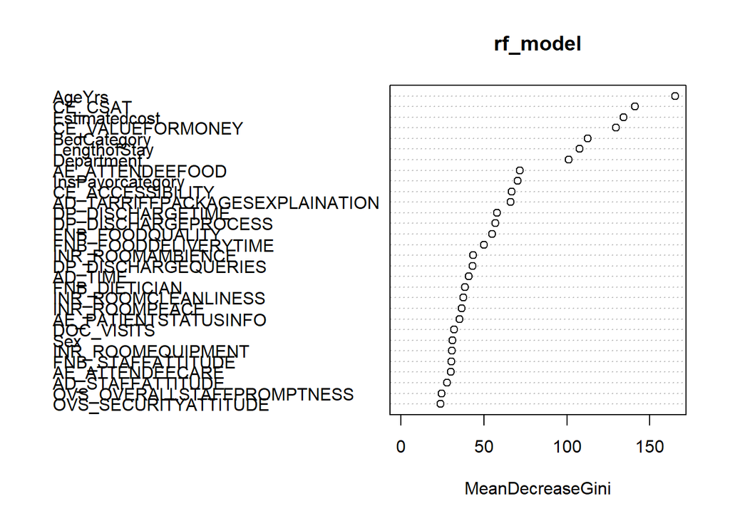

```r
varImpPlot(rf_model)
```

### Tuning the model to check optimal mtry and ntree

```
## mtry = 6  OOB error = 22.77%
## Searching left ...
## mtry = 3     OOB error = 22.69%
## 0.003521127 0.05
## Searching right ...
## mtry = 12    OOB error = 23.31%
## -0.02376761 0.05
```

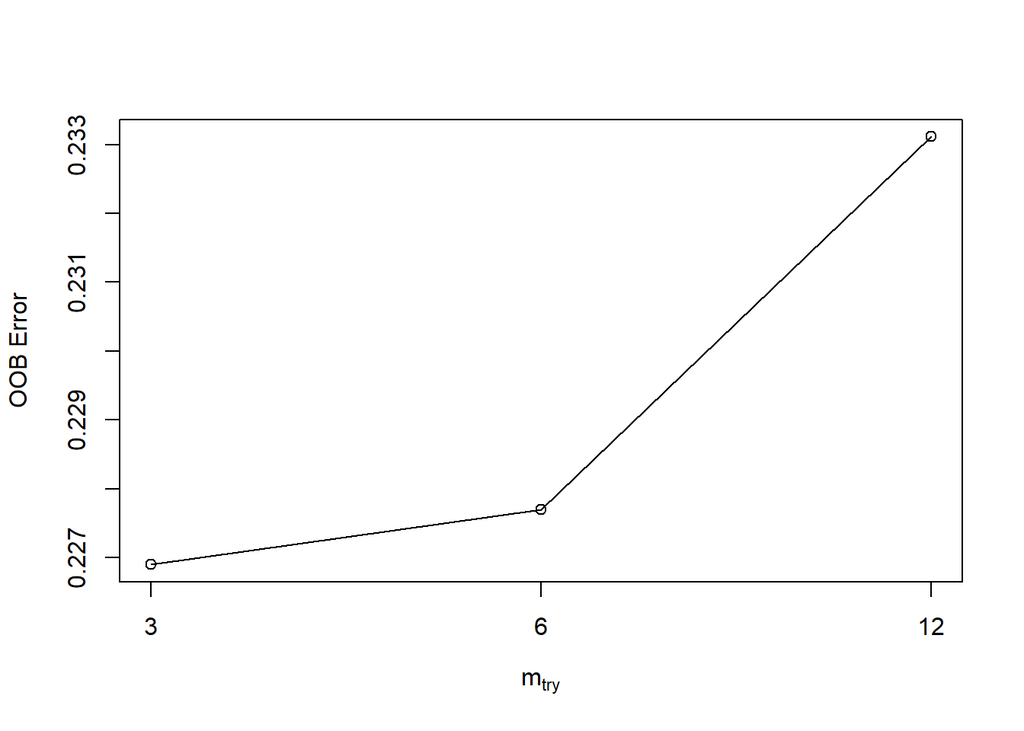

```
##        mtry  OOBError
## 3.OOB     3 0.2268992
## 6.OOB     6 0.2277009
## 12.OOB   12 0.2331128
```

```r
set.seed(2205)

tuneRF(train[, -44], train[, 44], stepFactor = 2, plot = T, ntreeTry = 500, improve = .05)
```

```
## mtry = 6  OOB error = 22.55%
## Searching left ...
## mtry = 3     OOB error = 22.73%
## -0.008 0.05
## Searching right ...
## mtry = 12    OOB error = 23.37%
## -0.03644444 0.05
```

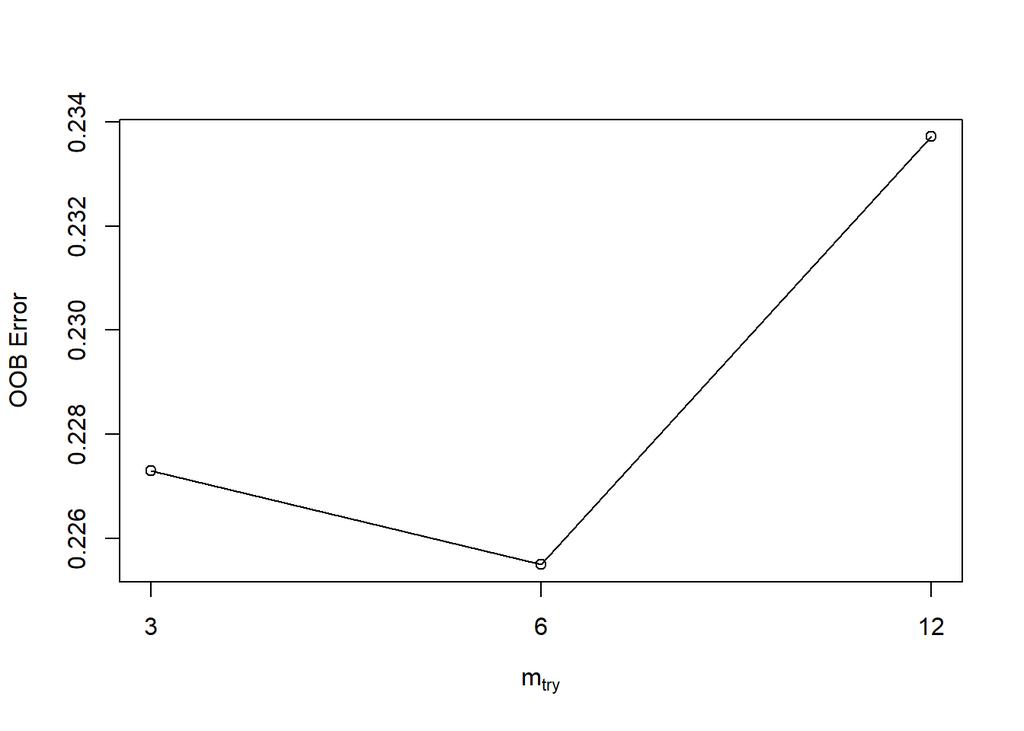

```
##        mtry  OOBError
## 3.OOB     3 0.2273001
## 6.OOB     6 0.2254961
## 12.OOB   12 0.2337142
```

```r
tuneRF(train[, -44], train[, 44], stepFactor = 2, plot = T, ntreeTry = 1000, improve = .05)
```

The lowest OOB error is found with mtry at 6 and ntree at 1000

### Building another RF model with mtry at 6 and ntree at 1000

```r
set.seed(2205)

rf_model2 <- randomForest(Detractor ~ ., data = train, mtry = 6, ntree = 1000)

print(rf_model2)
```

```
##
## Call:
##  randomForest(formula = Detractor ~ ., data = train, mtry = 6,      ntree = 1000)
##                Type of random forest: classification
##                      Number of trees: 1000
## No. of variables tried at each split: 6
##
##         OOB estimate of  error rate: 22.53%
## Confusion matrix:
##       No  Yes class.error
## No  2747  393   0.1251592
## Yes  731 1118   0.3953488
```

### Making predictions with the revised RF model on the test data

There was an error when entering the code below

“test$rf_pred <- predict(rf_model2, newdata = test, type =”class”)”

error:

“Error in predict.randomForest(rf_model2, newdata = test, type =”class”) : Type of predictors in new data do not match that of the training data.”

### Creating an alternate test dataset with 1 row from the train data

```r
test2 <- test

test2 <- test[ , -c(44, 45, 47:51)]

test2 <- rbind(train[1, ], test2)

test2 <- test2[-1, ]
```

### Making predictions with the revised RF model on the alternate test data

```r
test2$rf_pred <- predict(rf_model2, newdata = test2, type = "class")

test$rf_pred <- ifelse(test2$rf_pred == "Yes", "Detractor","Promotor")

test$rf_pred <- as.factor(test$rf_pred)
```

### Checking Model accuracy and fit

```r
confusionMatrix(test$rf_pred, test$NPS_Status, positive = "Detractor")
```

```
## Confusion Matrix and Statistics
##
##            Reference
## Prediction  Detractor Promotor
##   Detractor        95       31
##   Promotor         63      171
##
##                Accuracy : 0.7389
##                  95% CI : (0.6903, 0.7835)
##     No Information Rate : 0.5611
##     P-Value [Acc > NIR] : 2.188e-12
##
##                   Kappa : 0.4579
##
##  Mcnemar's Test P-Value : 0.001387
##
##             Sensitivity : 0.6013
##             Specificity : 0.8465
##          Pos Pred Value : 0.7540
##          Neg Pred Value : 0.7308
##              Prevalence : 0.4389
##          Detection Rate : 0.2639
##    Detection Prevalence : 0.3500
##       Balanced Accuracy : 0.7239
##
##        'Positive' Class : Detractor
##
```

```r
mean(test$rf_pred == test$NPS_Status)
```

```
## [1] 0.7388889
```

The Random Forest Model has an overall accuracy of 73% with Sensitivity & Specificity at 60% and 84% respectively.

## Traing a Linear and Radial SVM Models for Binomial Classification

### Balancing the train data

```r
train2 <- manipal_train

train2 <- train2[ , -c(1,2,10:12,48,49)]

train2[numeric] <- lapply(train2[numeric], factor)

train2 <- as.data.frame(unclass(train2), stringsAsFactors = T)

train2$Detractor <- ifelse(train2$NPS_Status == "Detractor", "Yes","No")

train2$Detractor <- as.factor(train2$Detractor)

train2 <- train2[ , -c(44, 45)]

t2_numeric <- sapply(train2, is.numeric)

t2_integer <- sapply(train2, is.integer)

t2_factor <- sapply (train2, is.factor)

df1 <- t2_numeric | t2_integer

df2 <- scale(train2[, df1])

df3 <- train2[, t2_factor]

train2_scaled <- data.frame(df2, df3)

train_bal <- ROSE(Detractor ~ ., data = train2_scaled, seed = 2205)$data

train_bal[numeric] <- lapply(train_bal[numeric], factor, levels= c("4","3","2","1"),
                             labels = c("Not at all Satisfied", "Less Satisfied",
                                        "Mostly Satisfied","Extremely Satisfied"),
                             ordered = TRUE)

table(train_bal$Detractor)
```

```
##
##   No  Yes
## 2500 2489
```

### Transforming the test data to match the balanced train data

```r
test3 <- manipal_test

test3 <- test3[ , -c(1,2,10:12,48,49)]

test3[numeric] <- lapply(test3[numeric], factor)

test3 <- as.data.frame(unclass(test3), stringsAsFactors = T)

test3$Detractor <- ifelse(test3$NPS_Status == "Detractor", "Yes","No")
test3$Detractor <- as.factor(test3$Detractor)

t3_numeric <- sapply(test3, is.numeric)

t3_integer <- sapply(test3, is.integer)

t3_factor <- sapply(test3, is.factor)

df_t3 <- t3_numeric | t3_integer

df_test3 <- scale(test3[, df_t3])

df2_test3 <- test3[, t3_factor]

test_scaled <- data.frame(df_test3, df2_test3)

test_scaled[numeric] <- lapply(test_scaled[numeric], factor, levels= c("4","3","2","1"),
                               labels = c("Not at all Satisfied", "Less Satisfied",
                                          "Mostly Satisfied","Extremely Satisfied"),
                               ordered = TRUE)

test_scaled <- test_scaled[!(test_scaled$NS_NURSEPROACTIVENESS == "Extremely Satisfied"), ]
```

### Building a SVM Model based on Linear Kernel

### Grid search for Linear Kernel

```r
set.seed (2205)

trControl <- trainControl(method = "cv",
                          number = 10)
```

### Define the tuning grid

```r
tuneGrid <- expand.grid(C = c(0.001, 0.01, 0.1, 1, 10))
```

### Training the linear model

```r
set.seed(2205)

linear_model <- train(Detractor ~ .,
                      data = train_bal,
                      method = "svmLinear",
                      trControl = trControl,
                      tuneGrid = tuneGrid)

print(linear_model)
```

```
## Support Vector Machines with Linear Kernel
##
## 4989 samples
##   43 predictor
##    2 classes: 'No', 'Yes'
##
## No pre-processing
## Resampling: Cross-Validated (10 fold)
## Summary of sample sizes: 4490, 4490, 4491, 4490, 4490, 4490, ...
## Resampling results across tuning parameters:
##
##   C      Accuracy   Kappa
##   1e-03  0.7163701  0.4328251
##   1e-02  0.7239845  0.4480012
##   1e-01  0.7271933  0.4543505
##   1e+00  0.7300006  0.4599334
##   1e+01  0.7300002  0.4599244
##
## Accuracy was used to select the optimal model using the largest value.
## The final value used for the model was C = 1.
```

### Making predictions with the linear model on the test data

```r
test$linear_pred <- predict(linear_model, newdata = test_scaled)

test$linear_pred <- ifelse(test$linear_pred == "Yes", "Detractor","Promotor")

test$linear_pred <- factor(test$linear_pred)
```

### Checking Model accuracy and fit

```r
confusionMatrix(test$linear_pred, test$NPS_Status, positive = "Detractor")
```

```
## Confusion Matrix and Statistics
##
##            Reference
## Prediction  Detractor Promotor
##   Detractor        94       58
##   Promotor         64      144
##
##                Accuracy : 0.6611
##                  95% CI : (0.6097, 0.7099)
##     No Information Rate : 0.5611
##     P-Value [Acc > NIR] : 6.896e-05
##
##                   Kappa : 0.3091
##
##  Mcnemar's Test P-Value : 0.6508
##
##             Sensitivity : 0.5949
##             Specificity : 0.7129
##          Pos Pred Value : 0.6184
##          Neg Pred Value : 0.6923
##              Prevalence : 0.4389
##          Detection Rate : 0.2611
##    Detection Prevalence : 0.4222
##       Balanced Accuracy : 0.6539
##
##        'Positive' Class : Detractor
##
```

```r
mean(test$linear_pred == test$NPS_Status)
```

```
## [1] 0.6611111
```

The Linear Kernel SVM Model has an overall accuracy of 66% with Sensitivity & Specificity at 59% and 71% respectively.

### Building a SVM Model based on Radial Kernel

### Define the tuning grid

```r
set.seed(2205)

param_grid <- expand.grid(C = c(0.1, 1, 10),
                          sigma = c(0.1, 1, 10))
```

### Training the Radial Model

```r
radial_model <- train(Detractor ~ .,
                      data = train_bal,
                      method = "svmRadial",
                      tuneGrid = param_grid,
                      trControl = trControl)
print(radial_model)
```

```
## Support Vector Machines with Radial Basis Function Kernel
##
## 4989 samples
##   43 predictor
##    2 classes: 'No', 'Yes'
##
## No pre-processing
## Resampling: Cross-Validated (10 fold)
## Summary of sample sizes: 4490, 4490, 4491, 4490, 4490, 4490, ...
## Resampling results across tuning parameters:
##
##   C     sigma  Accuracy   Kappa
##    0.1   0.1   0.6149705  0.2309608
##    0.1   1.0   0.5582873  0.1148766
##    0.1  10.0   0.5011026  0.0000000
##    1.0   0.1   0.8440588  0.6881834
##    1.0   1.0   0.8364375  0.6727429
##    1.0  10.0   0.6997396  0.3987190
##   10.0   0.1   0.8534849  0.7070588
##   10.0   1.0   0.8342315  0.6683417
##   10.0  10.0   0.7135705  0.4264568
##
## Accuracy was used to select the optimal model using the largest value.
## The final values used for the model were sigma = 0.1 and C = 10.
```

### Making predictions with the radial model on the test data

```r
test$radial_pred <- predict(radial_model, newdata = test_scaled)

test$radial_pred <- ifelse(test$radial_pred == "Yes", "Detractor","Promotor")

test$radial_pred <- factor(test$radial_pred)
```

### Checking Model accuracy and fit

```r
confusionMatrix(test$radial_pred, test$NPS_Status, positive = "Detractor")
```

```
## Confusion Matrix and Statistics
##
##            Reference
## Prediction  Detractor Promotor
##   Detractor       139      137
##   Promotor         19       65
##
##                Accuracy : 0.5667
##                  95% CI : (0.5137, 0.6185)
##     No Information Rate : 0.5611
##     P-Value [Acc > NIR] : 0.4376
##
##                   Kappa : 0.1864
##
##  Mcnemar's Test P-Value : <2e-16
##
##             Sensitivity : 0.8797
##             Specificity : 0.3218
##          Pos Pred Value : 0.5036
##          Neg Pred Value : 0.7738
##              Prevalence : 0.4389
##          Detection Rate : 0.3861
##    Detection Prevalence : 0.7667
##       Balanced Accuracy : 0.6008
##
##        'Positive' Class : Detractor
##
```

```r
mean(test$radial_pred == test$NPS_Status)
```

```
## [1] 0.5666667
```

The Radial Kernel SVM Model has an overall accuracy of 56% with Sensitivity & Specificity at 87% and 32% respectively.

## Model Comparison

```r
model_comparison <- data.frame(Model = c("Logistic Regression", "Step-wise Logistic Regression",
                                         "Over-Sampled Logistic Regression", "Decision Tree",
                                         "Pruned Decision Tree", "Random Forest", "Linear Kernel SVM",
                                         "Radial Kernel SVM"),
Accuracy = c(0.68,  0.70, 0.66, 0.65, 0.71, 0.73, 0.66, 0.56),
Sensitivity = c(0.51, 0.51, 0.60, 0.59, 0.58, 0.60, 0.59, 0.87),
Specificity = c(0.82, 0.84, 0.70, 0.70, 0.81, 0.84, 0.71, 0.32))

model_comparison
```

```
##                              Model Accuracy Sensitivity Specificity
## 1              Logistic Regression     0.68        0.51        0.82
## 2    Step-wise Logistic Regression     0.70        0.51        0.84
## 3 Over-Sampled Logistic Regression     0.66        0.60        0.70
## 4                    Decision Tree     0.65        0.59        0.70
## 5             Pruned Decision Tree     0.71        0.58        0.81
## 6                    Random Forest     0.73        0.60        0.84
## 7                Linear Kernel SVM     0.66        0.59        0.71
## 8                Radial Kernel SVM     0.56        0.87        0.32
```

As Manipal Hospital is seeking accurate identification and prediction of Detractors, the Radial Kernel SVM offers the highest Sensitivity at 87%. The model however, performs poorly on overall accuracy and Specificity. Depending on the organization decision to trade-off on Sensitivity for better accuracy and specificity, the Random Forest Model can be used for Detractor prediction as it offers a 73% accuracy with 60% Sensitivity and 84% Specificity.